# Practical Machine Learning Project

G. Lucas

May 24, 2015

## Overview

Using devices such as Jawbone Up, Nike FuelBand, and Fitbit it is now possible to collect a large amount of data about personal activity relatively inexpensively. These type of devices are part of the quantified self movement – a group of enthusiasts who take measurements about themselves regularly to improve their health, to find patterns in their behavior, or because they are tech geeks. One thing that people regularly do is quantify how much of a particular activity they do, but they rarely quantify how well they do it.

Six participants were asked to perform barbell lifts correctly and incorrectly in 5 different ways. More information is available from the website here: http://groupware.les.inf.puc-rio.br/har (see the section on the Weight Lifting Exercise Dataset). Data was captured from accelerometers on the belt, forearm, arm, and dumbbell of each participant.

The goal of this project is to predict the manner in which they did the exercise.

## Data Processing

```r
set.seed(333)
library(caret)
library(randomForest)
library(rpart)
library(rpart.plot)

setwd("~/Documents/Personal/Data Science Specialization/Practical Machine Learning/project")

train <- read.csv("pml-training.csv", na.strings=c("NA","#DIV/0!", ""))
test <- read.csv("pml-testing.csv", na.strings=c("NA","#DIV/0!", ""))

# Many columns are empty and therefore are dropped
train <- train[,colSums(is.na(train)) == 0]
test <- test[,colSums(is.na(test)) == 0]

#Drop the first 7 columns because they're not needed for model building and prediction
train <- train[,-c(1:7)]
test <- test[,-c(1:7)]
```

## Data Exploration

Size of the training and test sets

```r
dim(train)
```

```
[1] 19622    53
```

```r
dim(test)
```

```
[1] 20 53
```

Explore the classe variable in the training set

```r
summary(train$classe)
```

```
   A    B    C    D    E
5580 3797 3422 3216 3607
```

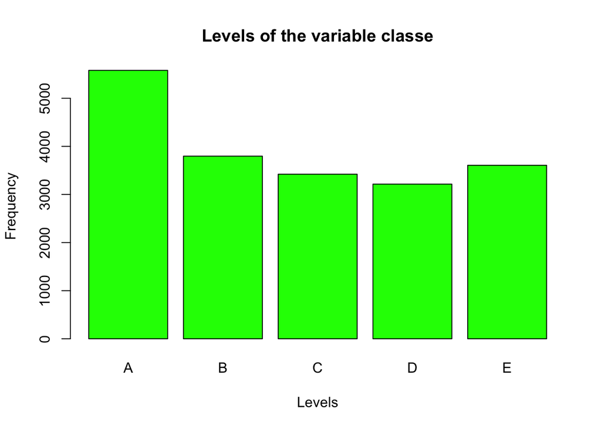

```r
plot(train$classe, col = "green",
     main = "Levels of the variable classe",
     xlab = "Levels", ylab = "Frequency")
```

## Model Development and Comparison

Create a data partition of the training set for cross validation

```r
samples <- createDataPartition(y = train$classe, p  = 0.75, list = FALSE)
subTrain <- train[samples, ]
subTest <- train[-samples, ]
dim(subTrain)
```

```
[1] 14718    53
```

```r
dim(subTest)
```

```
[1] 4904   53
```

Develop model using Recursive Partition

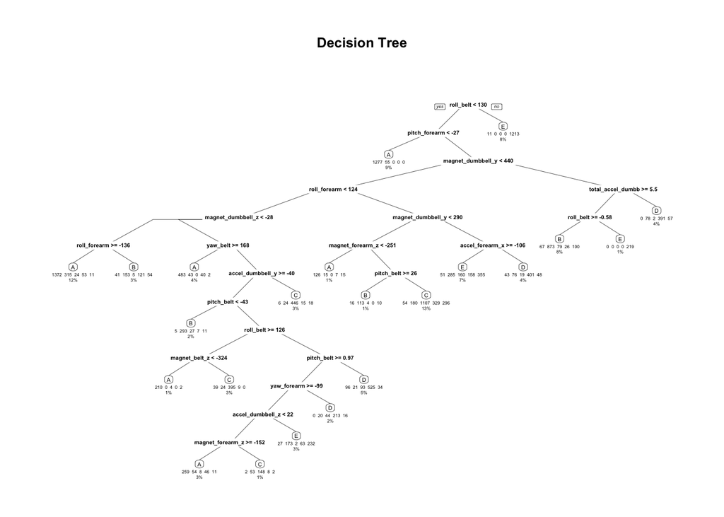

```r
# Predict using Recursive Partition
rpartModel <- rpart(classe ~ ., data = subTrain, method = "class")
rpartPrediction<- predict(rpartModel, subTest, type = "class")

# Decision Tree
rpart.plot(rpartModel, main = "Decision Tree", extra = 101, under = TRUE)
```

```r
confusionMatrix(rpartPrediction, subTest$classe)
```

```
Confusion Matrix and Statistics

          Reference
Prediction    A    B    C    D    E
         A 1256  172   14   46   16
         B   27  458   37   55   53
         C   36   91  682  120  112
         D   48   68   60  506   37
         E   28  160   62   77  683

Overall Statistics

               Accuracy : 0.731
                 95% CI : (0.7184, 0.7434)
    No Information Rate : 0.2845
    P-Value [Acc > NIR] : < 2.2e-16

                  Kappa : 0.6591
 Mcnemar's Test P-Value : < 2.2e-16

Statistics by Class:

                     Class: A Class: B Class: C Class: D Class: E
Sensitivity            0.9004  0.48261   0.7977   0.6294   0.7580
Specificity            0.9293  0.95651   0.9113   0.9480   0.9183
Pos Pred Value         0.8351  0.72698   0.6551   0.7038   0.6762
Neg Pred Value         0.9591  0.88512   0.9552   0.9288   0.9440
Prevalence             0.2845  0.19352   0.1743   0.1639   0.1837
Detection Rate         0.2561  0.09339   0.1391   0.1032   0.1393
Detection Prevalence   0.3067  0.12847   0.2123   0.1466   0.2060
Balanced Accuracy      0.9148  0.71956   0.8545   0.7887   0.8382
```

```r
rpartAccuracy <- round(as.numeric(
        confusionMatrix(rpartPrediction, subTest$classe)$overall[[1]]) * 100,
        digits=2)
```

Accuracy using Recursive Partitioning is 73.1%

Develop model using Random Forest

```r
# Predict using Random Forest
rForestModel <- randomForest(classe ~. , data = subTrain, method="class")
rForestPrediction <- predict(rForestModel, subTest, type = "class")

# Test results on subTesting data set:
confusionMatrix(rForestPrediction, subTest$classe)
```

```
Confusion Matrix and Statistics

          Reference
Prediction    A    B    C    D    E
         A 1395    4    0    0    0
         B    0  942    5    0    0
         C    0    3  849    9    0
         D    0    0    1  795    1
         E    0    0    0    0  900

Overall Statistics

               Accuracy : 0.9953
                 95% CI : (0.993, 0.997)
    No Information Rate : 0.2845
    P-Value [Acc > NIR] : < 2.2e-16

                  Kappa : 0.9941
 Mcnemar's Test P-Value : NA

Statistics by Class:

                     Class: A Class: B Class: C Class: D Class: E
Sensitivity            1.0000   0.9926   0.9930   0.9888   0.9989
Specificity            0.9989   0.9987   0.9970   0.9995   1.0000
Pos Pred Value         0.9971   0.9947   0.9861   0.9975   1.0000
Neg Pred Value         1.0000   0.9982   0.9985   0.9978   0.9998
Prevalence             0.2845   0.1935   0.1743   0.1639   0.1837
Detection Rate         0.2845   0.1921   0.1731   0.1621   0.1835
Detection Prevalence   0.2853   0.1931   0.1756   0.1625   0.1835
Balanced Accuracy      0.9994   0.9957   0.9950   0.9942   0.9994
```

```r
rfAccuracy <- round(as.numeric(
        confusionMatrix(rForestPrediction, subTest$classe)$overall[[1]]) * 100,
        digits=2)
```

Random Forest accuracy is 99.53% which is much more accurate than Recursive Partitioning. Therefore, Random Forest will be used to forecast.

## Create Final Prediction

```r
predictfinal <- predict(rForestModel, test, type="class")
predictfinal
```

```
 1  2  3  4  5  6  7  8  9 10 11 12 13 14 15 16 17 18 19 20
 B  A  B  A  A  E  D  B  A  A  B  C  B  A  E  E  A  B  B  B
Levels: A B C D E
```

Review the final results

```r
summary(predictfinal)
```

```
A B C D E
7 8 1 1 3
```

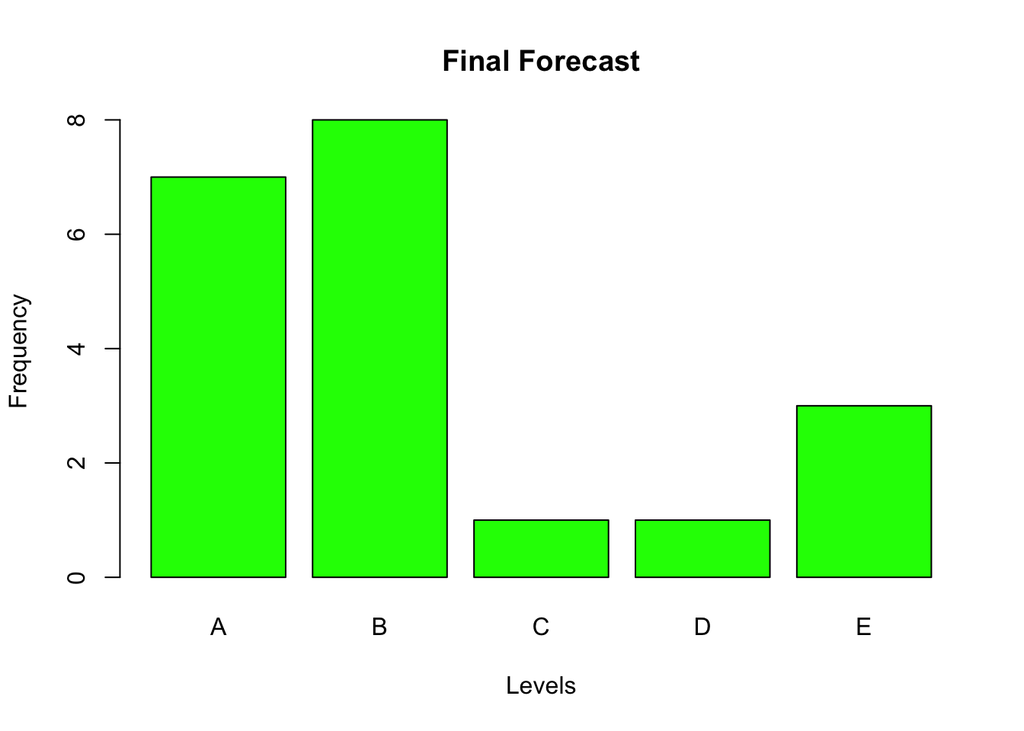

```r
plot(predictfinal, col = "green",
     main = "Final Forecast",
     xlab = "Levels", ylab = "Frequency")
```